# Data Visualization Using R

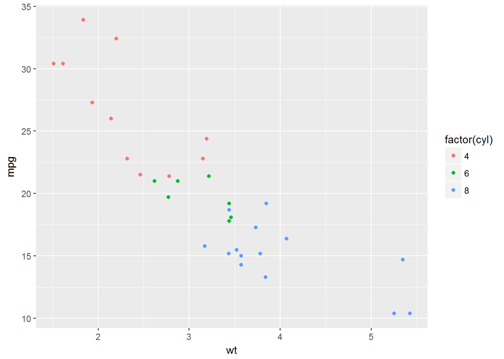

```r
m + geom_point(aes(colour=factor(cyl)))
```

- How about the effect of both clarity and cut?

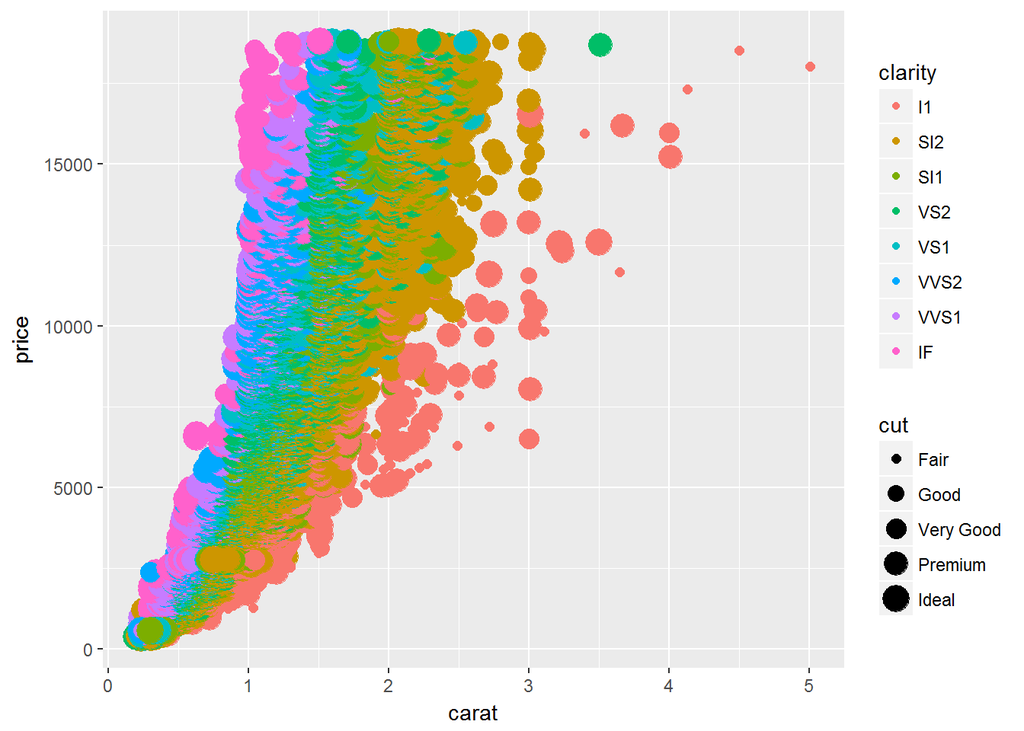

```r
d + geom_point(aes(colour=clarity, size=cut))
```

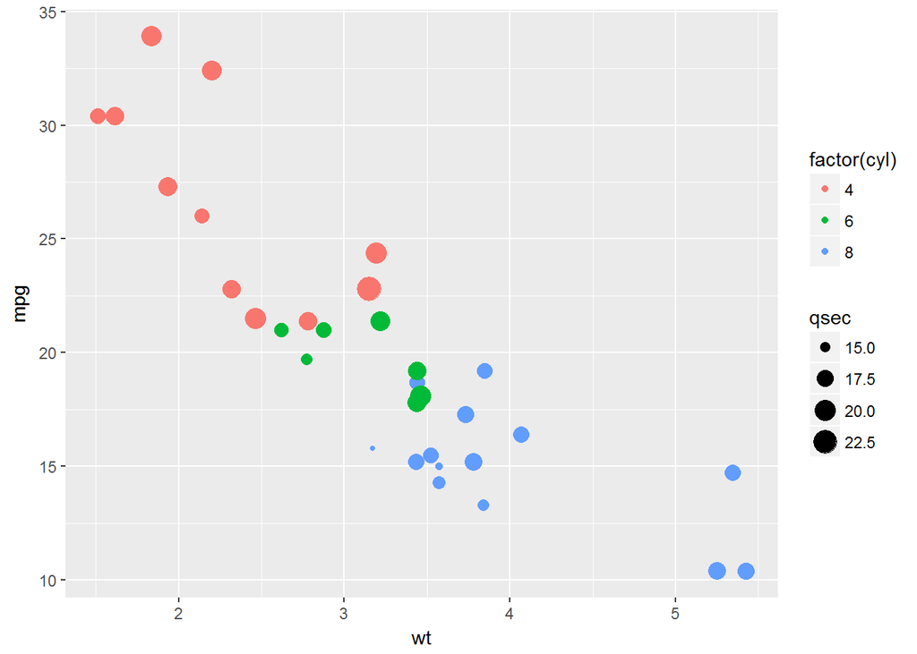

```r
m + geom_point(aes(colour=factor(cyl), size = qsec))
```

- We could use the shape to represent the cut:

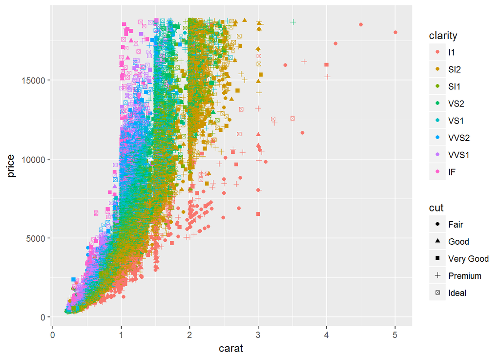

```r
d + geom_point(aes(colour=clarity, shape=cut))
```

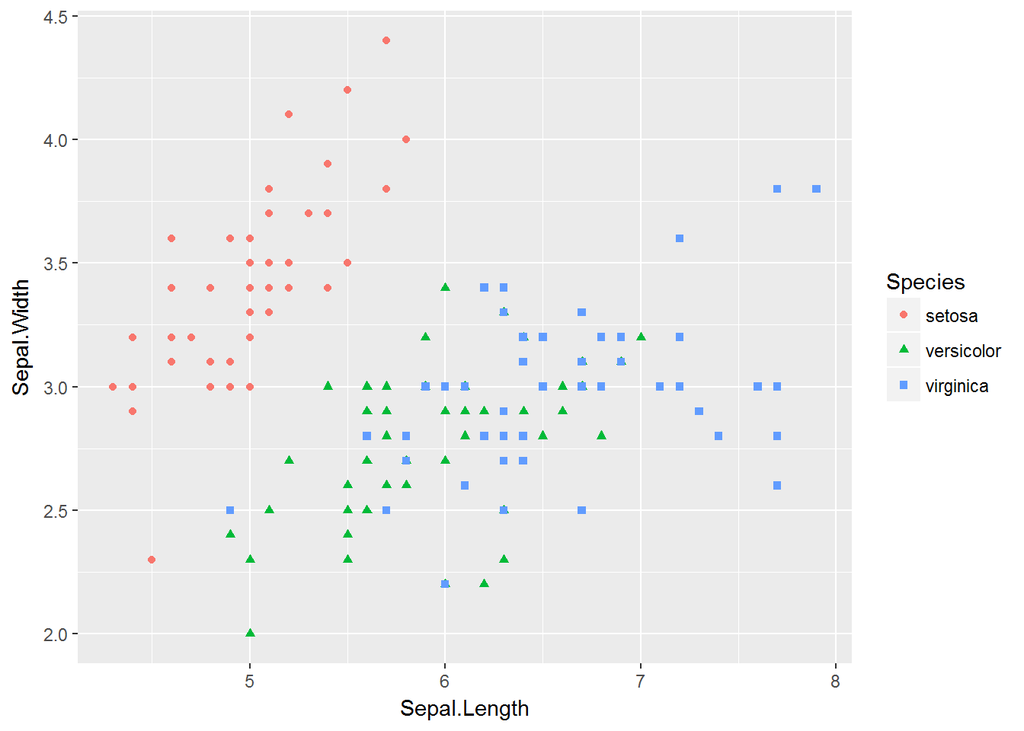

```r
i + geom_point(aes(colour=Species, shape=Species))
```

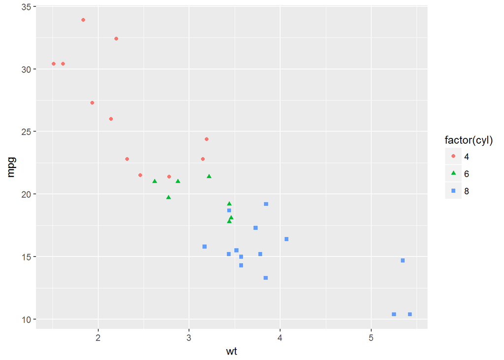

```r
m + geom_point(aes(colour = factor(cyl), shape = factor(cyl)))
```

- Up to now, we have been working with one layer, but we can add more by using the plus sign. To observe this, lets use the `geom_smooth` layer, which adds a smoothing curve that shows the general trend of the data:

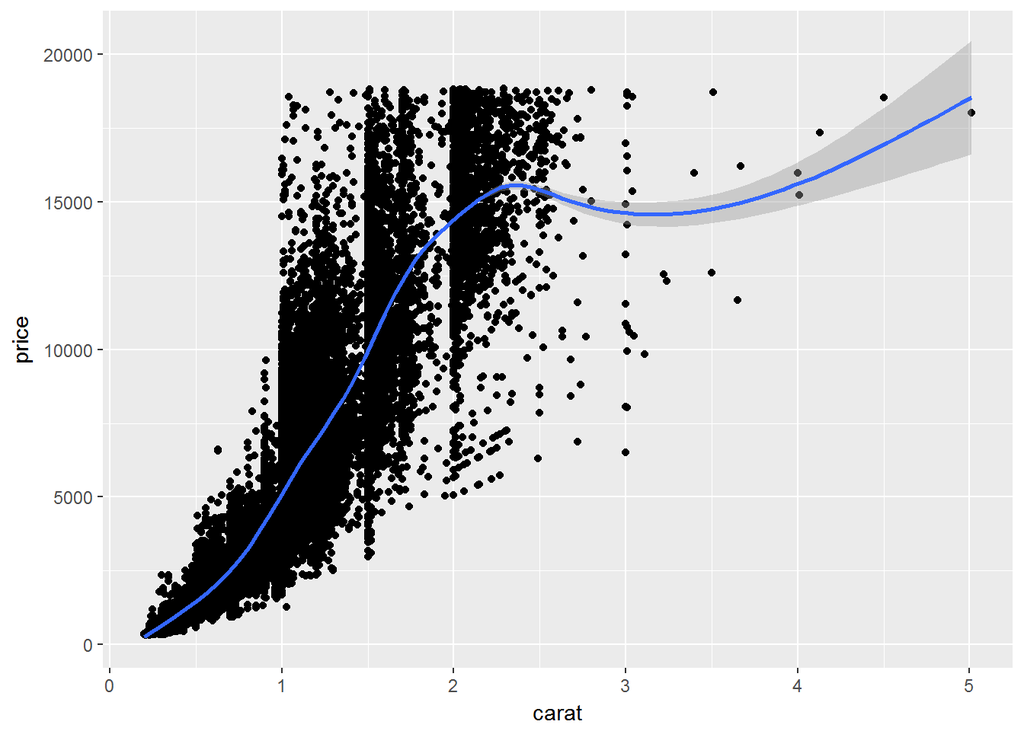

```r
d + geom_point() + geom_smooth()
```

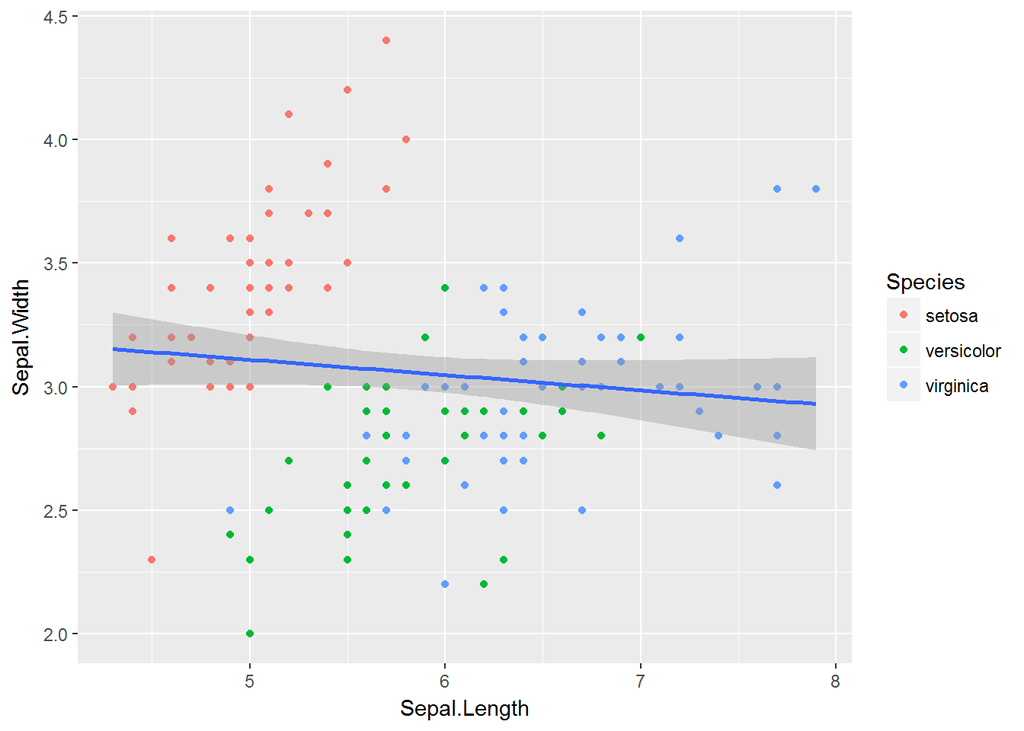

```r
i + geom_point(aes(colour = Species)) + geom_smooth(method = "lm")
```

- The gray area around the curve is a confidence interval, suggesting how much uncertainty there is in this smoothing curve. If we want to turn off the confidence interval, we can add an option to the `geom_smooth` later; specifically “se=FALSE”, where “s.e.” stands for “standard error.

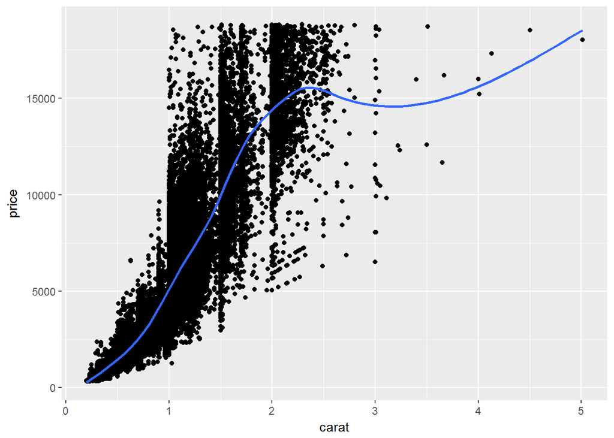

```r
d + geom_point() + geom_smooth(se=FALSE)
```

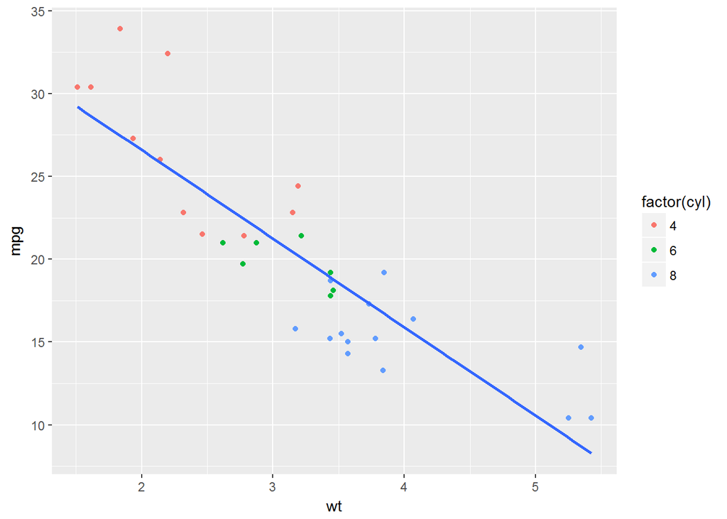

```r
m + geom_point(aes(colour = factor(cyl))) + geom_smooth(method="lm", se=FALSE)
```

## Faceting and Additional Options

- “Faceting” is another way of communicating information by dividing your plot into multiple plots, one for each level, letting you view them separately. This is done in ggplot with the `facet_wrap()` function where you put a tilde (~) along with the attribute you would like to divide the plots by.

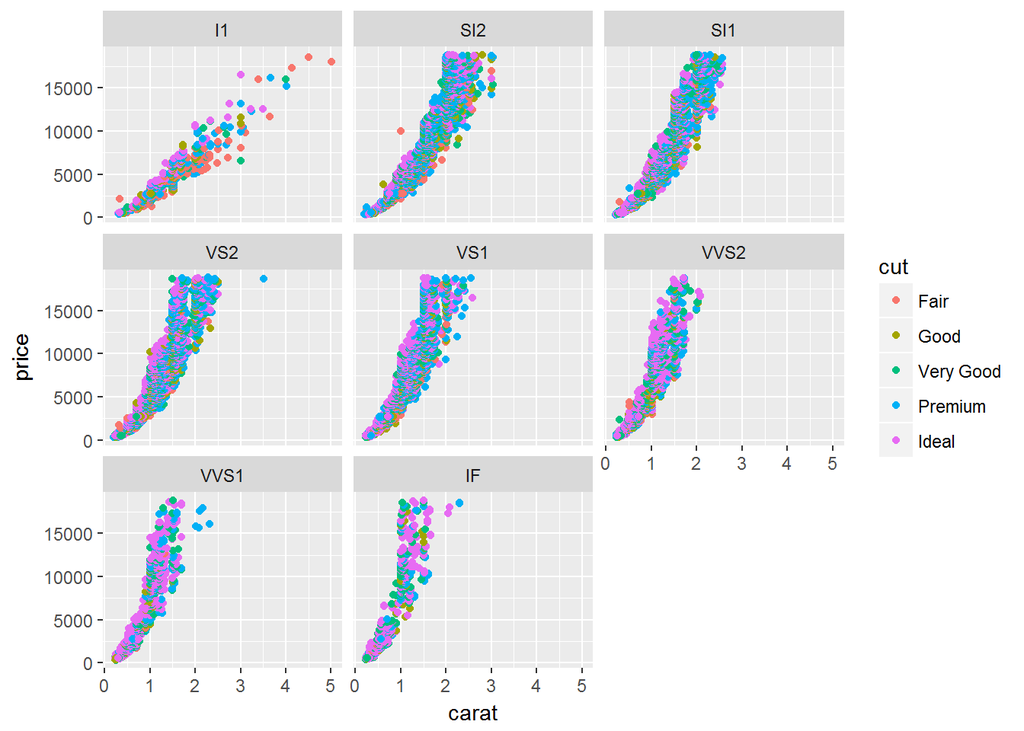

```r
d + geom_point(aes(colour=cut)) + facet_wrap(~ clarity)
```

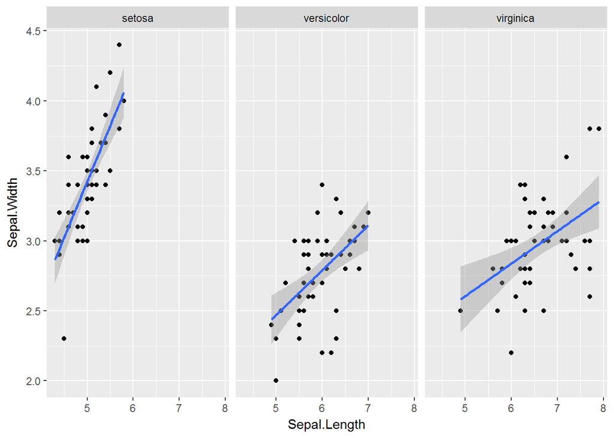

```r
i + geom_point() + facet_grid(. ~ Species) + geom_smooth(method = "lm")
```

- You can even divide your graph based on two different attributes, such as both color and clarity, using `facetgrid()`. In this case that would be “facetgrid(”, then you put “color ~ clarity”, where the tilde (~) means “explained by.”

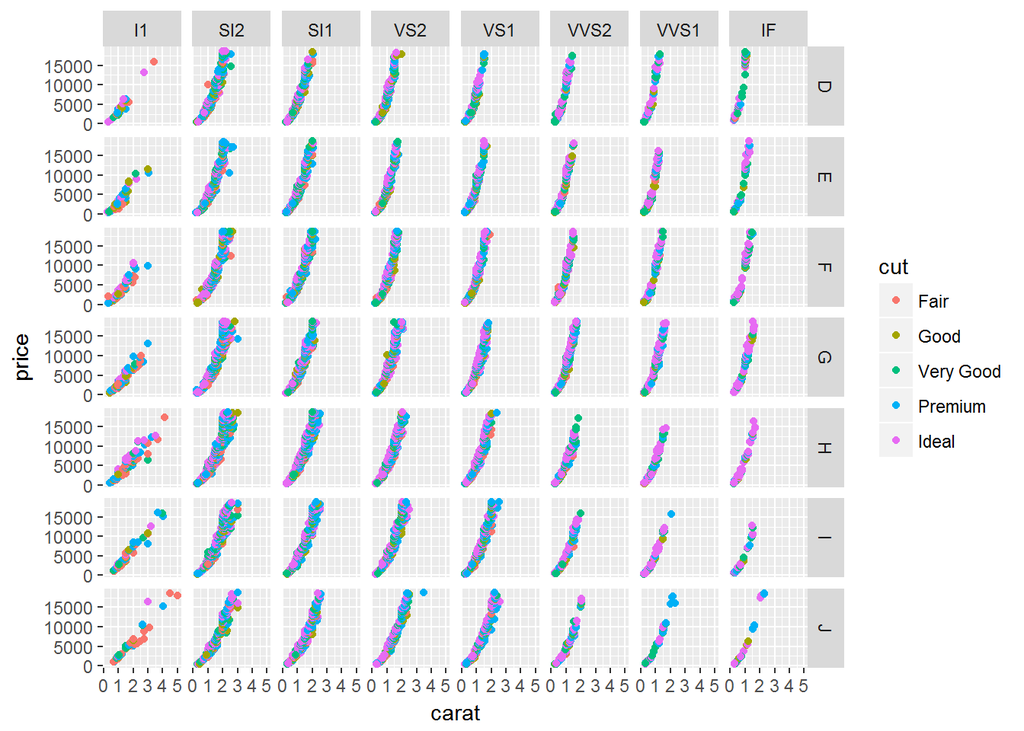

```r
d + geom_point(aes(colour=cut)) + facet_grid(color ~ clarity)
```

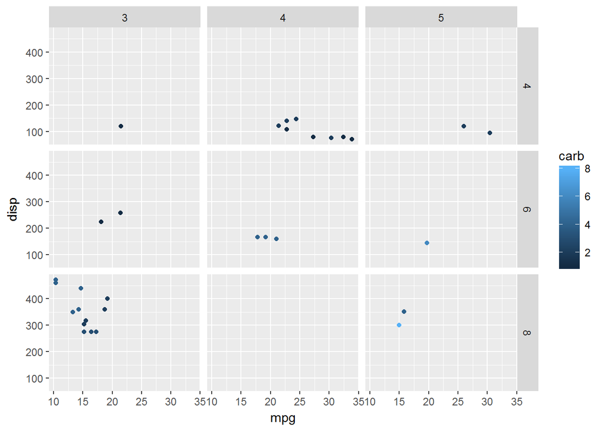

```r
ggplot(data=mtcars, aes(x=mpg, y=disp)) +
  geom_point(aes(color = carb)) +
  facet_grid(cyl ~ gear)
```

- You might want to set a title, or set the x or y axis labels manually. You change these options by adding to the end of the line of code. To set the title, you would use the ggtitle function:

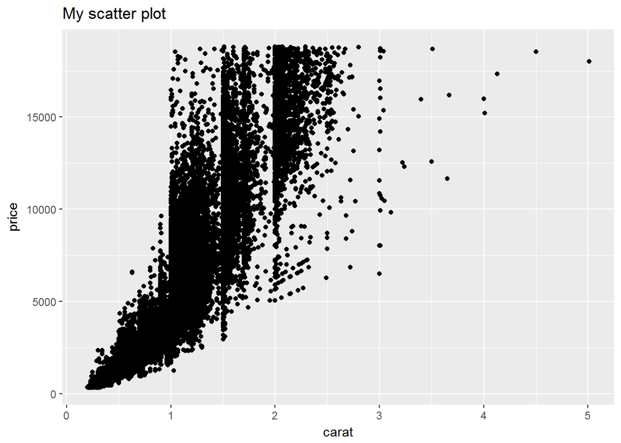

```r
d + geom_point() + ggtitle("My scatter plot")
```

- To change the x- or y- axis labels, you would add “xlab” for “x label”, then your custom label:

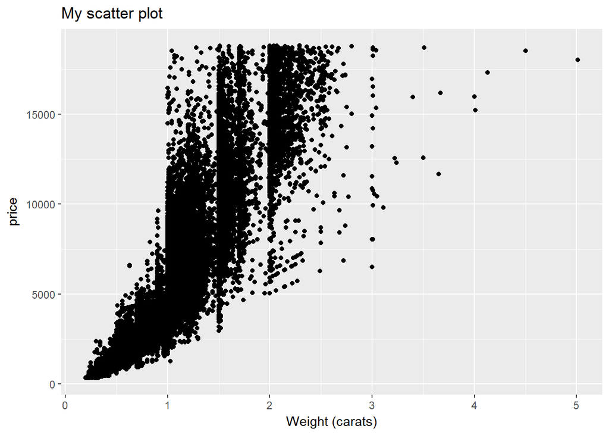

```r
ggplot(diamonds, aes(x=carat, y=price)) +
  geom_point() +
  ggtitle("My scatter plot") +
  xlab("Weight (carats)")
```

- You might also want to limit the range of the x or the y axes. You can do this with the xlim or ylim options:

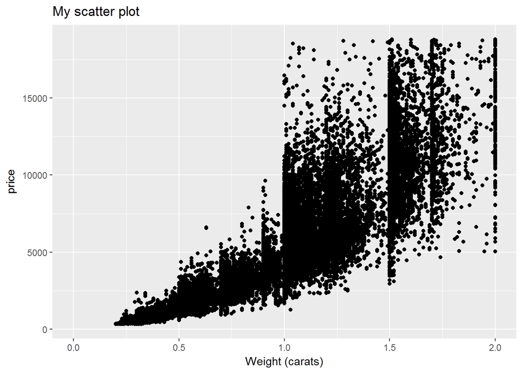

```r
ggplot(diamonds, aes(x=carat, y=price)) +
  geom_point() +
  ggtitle("My scatter plot") +
  xlab("Weight (carats)") +
  xlim(0, 2)
```

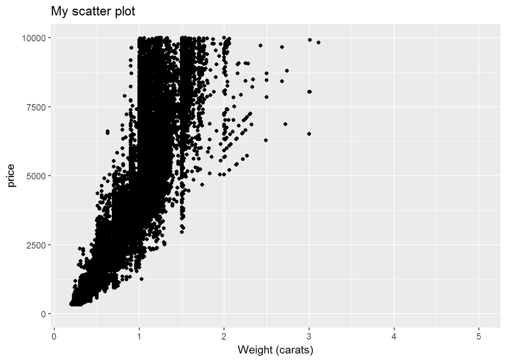

```r
ggplot(diamonds, aes(x=carat, y=price)) +
  geom_point() +
  ggtitle("My scatter plot") +
  xlab("Weight (carats)") +
  ylim(0, 10000)
```

- Another possibility is to put one of the axes on a log scale. You can do this with the scale_y_log10() function:

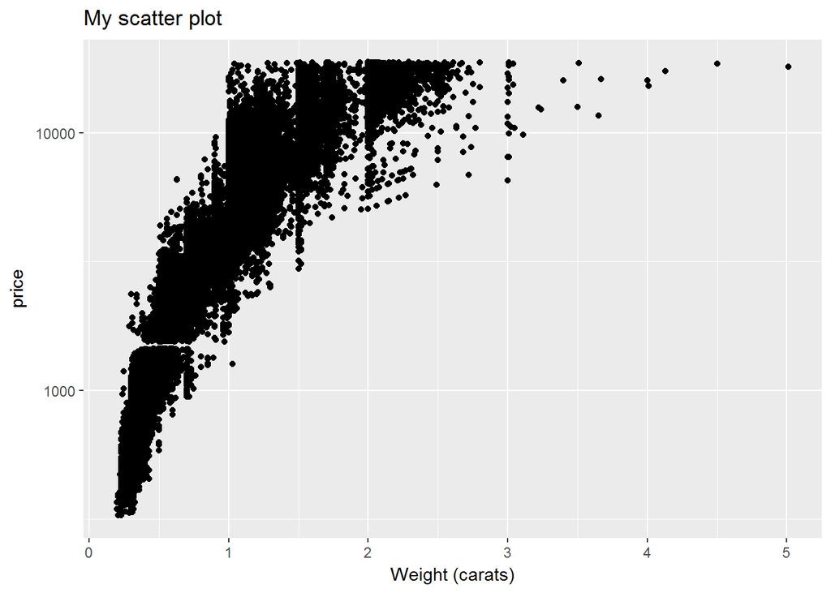

```r
ggplot(diamonds, aes(x=carat, y=price)) +
  geom_point() +
  ggtitle("My scatter plot") +
  xlab("Weight (carats)") +
  scale_y_log10()
```

- There are many other available options and customizations: each gets added to the end of the plot just like these.

## Line Graphs

- For line graphs, the data points must be grouped so that it knows which points to connect.

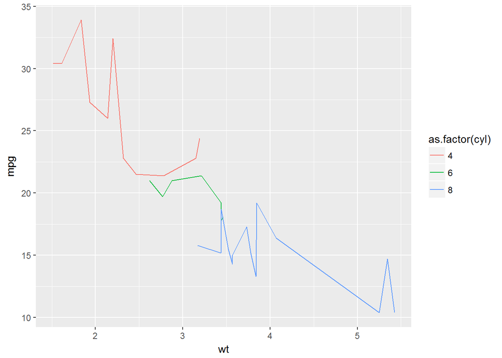

```r
m + geom_line(aes(colour = as.factor(cyl)))
```

## Histograms and Density Plots

- To look at just one dimension of your data and observe its distribution, we can use a histogram, and all you need to do from before is to change your layer from `geom_point()` to `geom_histogram()`:

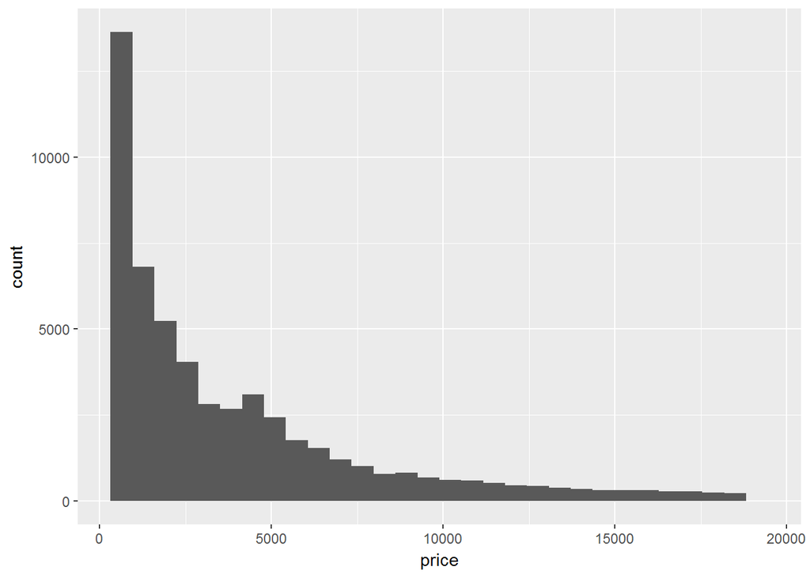

```r
ggplot(diamonds, aes(x=price)) +
  geom_histogram()
```

- You can change the width of each bin as an option to the `geom_histogram` layer. You can make them wider or thinner:

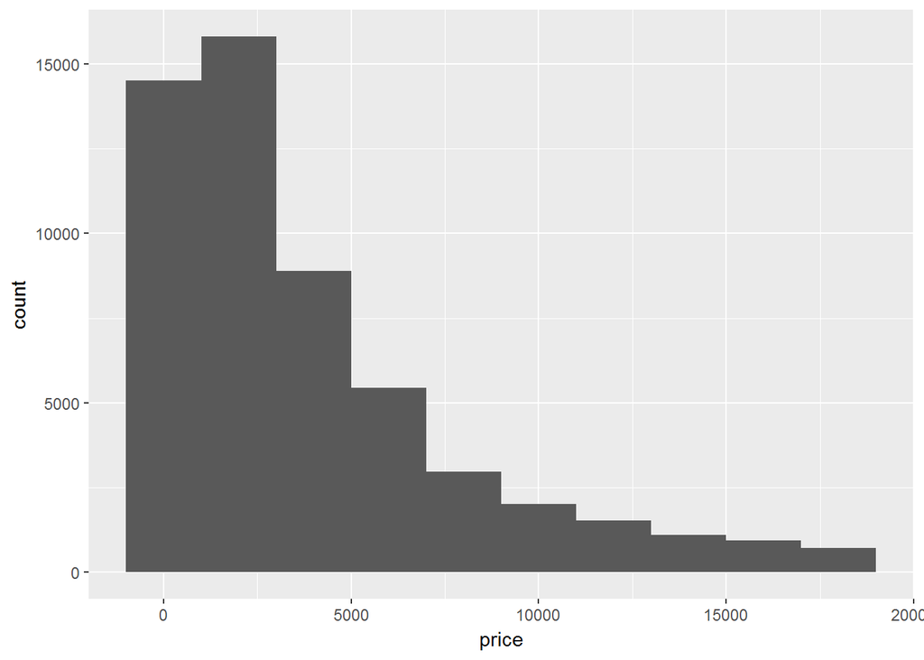

```r
ggplot(diamonds, aes(x=price)) +
  geom_histogram(binwidth=2000)
```

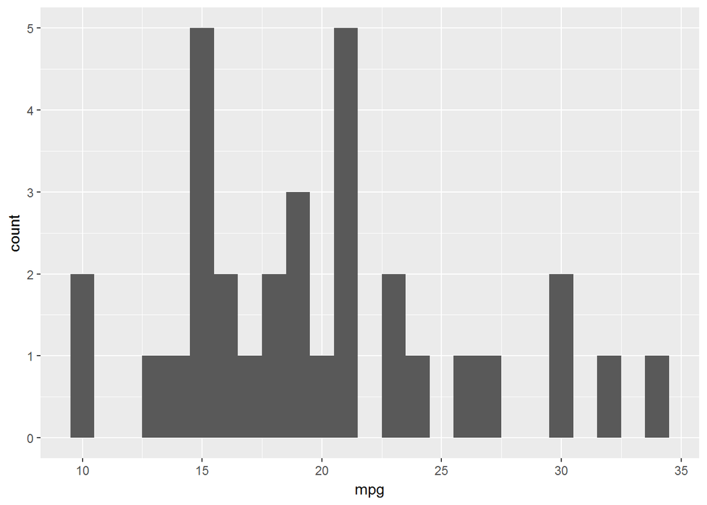

```r
ggplot(data = mtcars, aes(x = mpg, fill=cyl)) +
  geom_histogram(binwidth = 1)
```

- Let’s say you want to add another attribute to this histogram to see its effect on the density: for example, to make a stacked histogram based on the clarity attribute. Try adding the “fill” aesthetic:

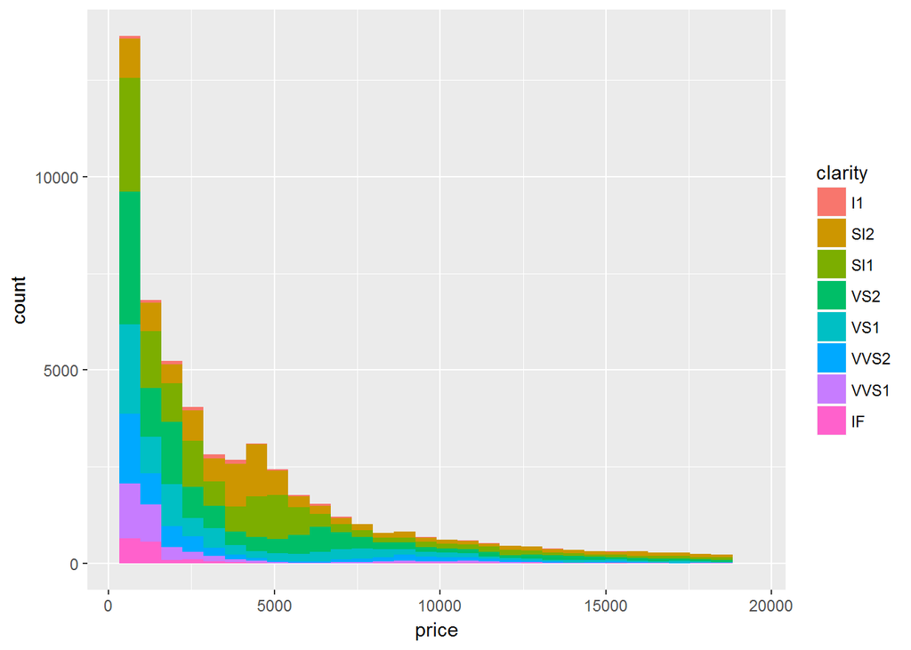

```r
ggplot(diamonds, aes(x=price, fill=clarity)) +
  geom_histogram()
```

- Another way to view the distribution is as a density curve. You can do this by changing `geom_histogram` to `geom_density`. Remove the fill attribute.

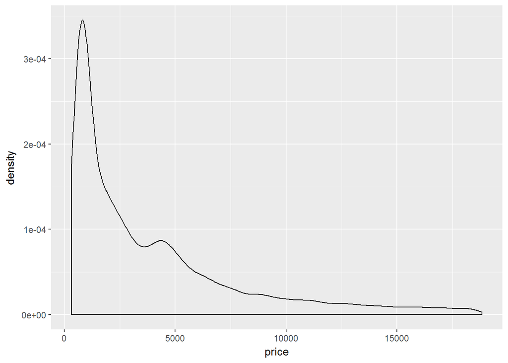

```r
ggplot(diamonds, aes(x=price)) +
  geom_density()
```

- If you want to divide this density curve up based on one of your attributes, you can use the `color` aesthetic instead of `fill`. For example, you can add `color=cut`.

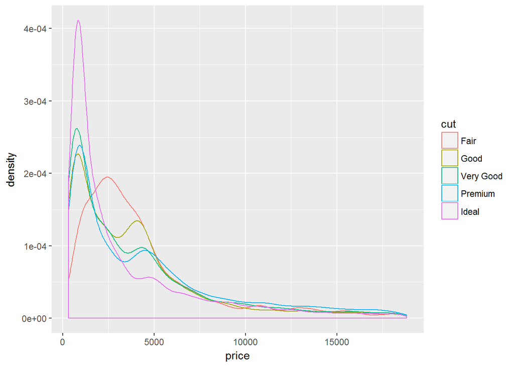

```r
ggplot(diamonds, aes(x=price, color=cut)) +
  geom_density()
```

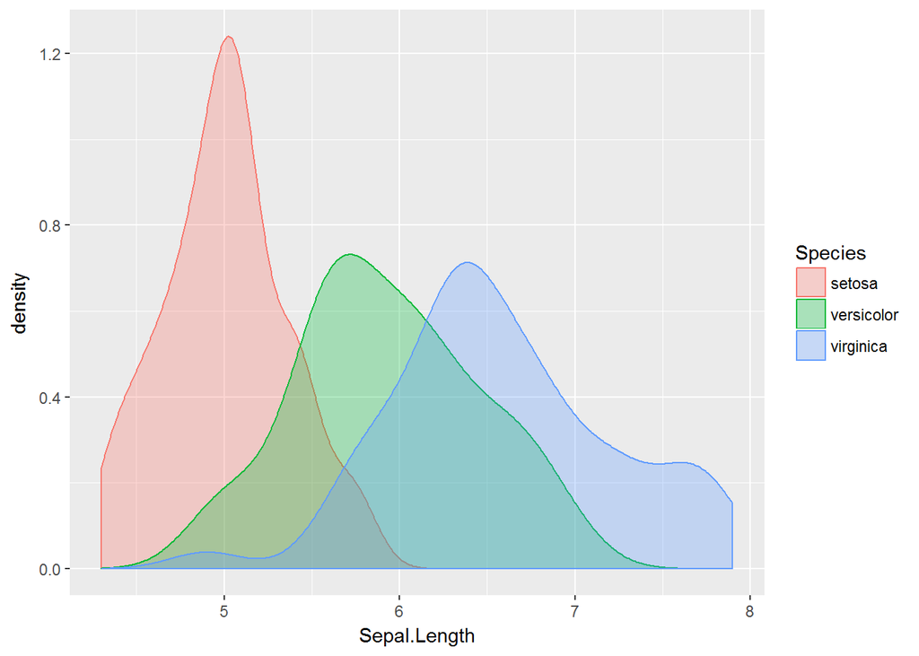

```r
ggplot(iris, aes(x = Sepal.Length, color = Species, fill=Species)) +
  geom_density(alpha=0.3)
```